# Agile Portfolio Management (APM) Visuals

This is an R Markdown document for the ApmVisuals package, which uses **ggplot2** to create custom visualizations for Agile Portfolio managers. These visuals were derived from guidance from the [Scaled Agile Framework (SAFe) site](http://www.scaledagileframework.com).

These visualizations include: 1. Epic Burn-Up Chart 2. WSJF Comparison Chart 3. Investment Opportunit Schedule 4. Epic Progress Bar Chart

## Epic Burn-Up Chart

The **Epic Burn-Up Chart** depicts the initial estimate in story points, actual story points completed, and cumulative story points completed over time. Therefore, the **generateEpicBurnUp** function takes the following parameters: 1. **iterationName** - a vector of iteration names in chronological order, 2. **initialEstimate** - a vector of initialEstimates, 3. **actualStoryPoints** - the actual story points completed in an iteration, and 4. **cumulativeStoryPoints** - a running sum of the storyPoints iteration to iteration.

The following depicts and example of the **Epic Burn-Up Chart**:

```r
#Epic Burn-Up Chart Visual Example
iterationName <- c("PI 1 - Iteration 1", "PI 1 - Iteration 2", "PI 1 - Iteration 3", "PI 1 - Iteration 4", "PI 1 - Iteration 5", "PI 1 - Iteration 6")
initialEstimate <- c(500, 500, 550, 550, 570, 570)
actualStoryPoints <- c(75, 65, 78, 108, 115, 130)
cumulativeStoryPoints <- cumsum(actualStoryPoints)
df <- data.frame(iterationName, initialEstimate, actualStoryPoints, cumulativeStoryPoints)
print(df)
```

```
##        iterationName initialEstimate actualStoryPoints
## 1 PI 1 - Iteration 1             500                75
## 2 PI 1 - Iteration 2             500                65
## 3 PI 1 - Iteration 3             550                78
## 4 PI 1 - Iteration 4             550               108
## 5 PI 1 - Iteration 5             570               115
## 6 PI 1 - Iteration 6             570               130
##   cumulativeStoryPoints
## 1                    75
## 2                   140
## 3                   218
## 4                   326
## 5                   441
## 6                   571
```

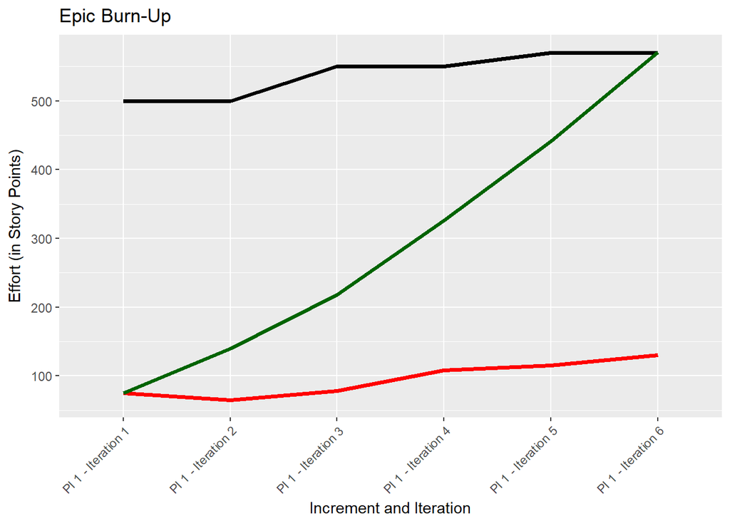

```r
generateEpicBurnUp(iterationName, initialEstimate, actualStoryPoints, cumulativeStoryPoints)
```

## WSJF Comparison Chart

The **WSJF Comparison Chart** depicts the Cost of Delay against the estiamted Duration (in Iterations) of a given Feature. Therefore, the **generateWsjf** function takes the following parameters: 1. **featureName** - vector of feature names, 2. **duration** - vector of durations, and 3. **cod** - vector of cost of delay.

The following depicts an example of the **WSJF Comparison Chart**:

```r
#WSJF Visual Example
featureName <- c("Feature #1", "Feature #2", "Feature #3", "Feature #4", "Feature #5", "Feature #6", "Feature #7", "Feature #8", "Feature #9", "Feature #10")
duration <- c(2, 4, 7, 8, 3, 4, 4, 5, 10, 12)
cod <- c(12.0, 4.25, 7.5, 3.333, 5.0, 6.0, 13.75, 10.0, 2.25, 1.25)
df <- data.frame(featureName, duration, cod)
print(df)
```

```
##    featureName duration    cod
## 1   Feature #1        2 12.000
## 2   Feature #2        4  4.250
## 3   Feature #3        7  7.500
## 4   Feature #4        8  3.333
## 5   Feature #5        3  5.000
## 6   Feature #6        4  6.000
## 7   Feature #7        4 13.750
## 8   Feature #8        5 10.000
## 9   Feature #9       10  2.250
## 10 Feature #10       12  1.250
```

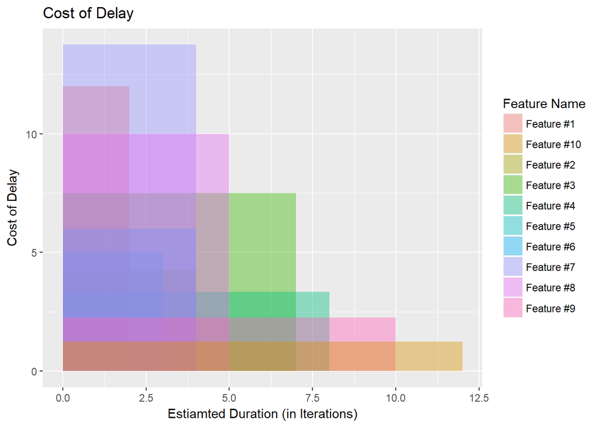

```r
generateWsjf(featureName, duration, cod)
```

## Investment Opportunity Schedule

The **Investment Opportunity Schedule** provides an alternative visual to standard SAFe metrics that leverages a concept from investment planning, which compares Internal Rate of Return vs. Capital Costs. Therefore the **generateIos** function take the following parameters: 1. **projectName** - the epic or project name, 2. **projectReturnRate** - the anticipated return rate in decimal format, and 3. **projectCost** - estiamted cost in USD.

The following depicts an example of the **Investment Opportunity Schedule**:

```r
#IOS Visual Example
projectName <- c("Epic #1", "Epic #2", "Epic #3", "Epic #4", "Epic #5", "Epic #6")
projectReturnRate <- c(.10, .22, .05, .12, .30, .09)
projectCost <- c(124000, 212000, 153000, 420000, 75000, 98000)
df <- data.frame(projectName, projectReturnRate, projectCost)
print(df)
```

```
##   projectName projectReturnRate projectCost
## 1     Epic #1              0.10      124000
## 2     Epic #2              0.22      212000
## 3     Epic #3              0.05      153000
## 4     Epic #4              0.12      420000
## 5     Epic #5              0.30       75000
## 6     Epic #6              0.09       98000
```

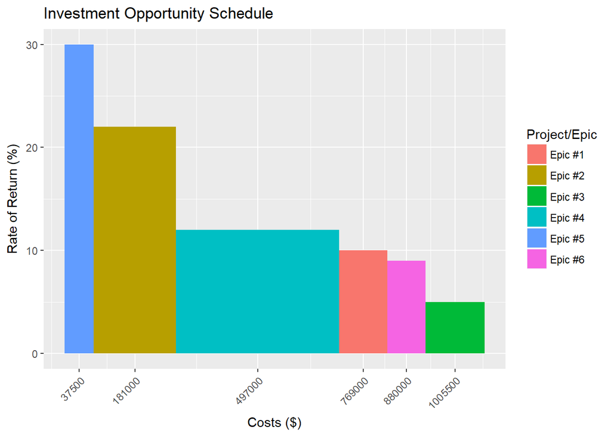

```r
generateIos(projectName, projectReturnRate, projectCost)
```

## Epic Progress Bar Chart

The **Epic Progress Bar Chart** depicts completed story points against the remaning and total points for a given epic or project. Therefore the **generateEpicProgress** function takes the following parameters: 1. **epicName** - the name of the epic or project, 2. **totalFeaturePoints** - the sum of all story points for a given feature, 3. **completedStoryPoints** - the sum of all story points for a given feature where the status is Done, and 4. the **initialEstimates** - the initial estimates (in story points) for a given epic.

*Note: The startDate and targetDate fields are currently not used, but are required. The function will be updated in the future to use these values for additional indicators.*

The following depicts an example of the **Epic Progress Bar Chart**:

```r
#Epic Progres Bars Visual Example
epicNames <- c("Epic #1", "Epic #2", "Epic #3", "Epic #4", "Epic #5", "Epic #6")
totalFeaturePoints <- c(100, 230, 150, 95, 78, 176)
completedFeaturePoints <- c(50, 170, 94, 34, 40, 125)
initialEstimates <- c(120, 200, 140, 100, 50, 200)
startDates <- c("2018-02-22", "2018-02-22", "2018-04-22", "2018-06-22", "2018-08-22", "2018-09-22")
targetDates <- c("2018-03-22", "2018-05-22", "2018-07-22", "2018-09-22", "2018-11-22", "2018-12-22")
df <- data.frame(epicNames, totalFeaturePoints, completedFeaturePoints, initialEstimates, startDates, targetDates)
print(df)
```

```
##   epicNames totalFeaturePoints completedFeaturePoints initialEstimates
## 1   Epic #1                100                     50              120
## 2   Epic #2                230                    170              200
## 3   Epic #3                150                     94              140
## 4   Epic #4                 95                     34              100
## 5   Epic #5                 78                     40               50
## 6   Epic #6                176                    125              200
##   startDates targetDates
## 1 2018-02-22  2018-03-22
## 2 2018-02-22  2018-05-22
## 3 2018-04-22  2018-07-22
## 4 2018-06-22  2018-09-22
## 5 2018-08-22  2018-11-22
## 6 2018-09-22  2018-12-22
```

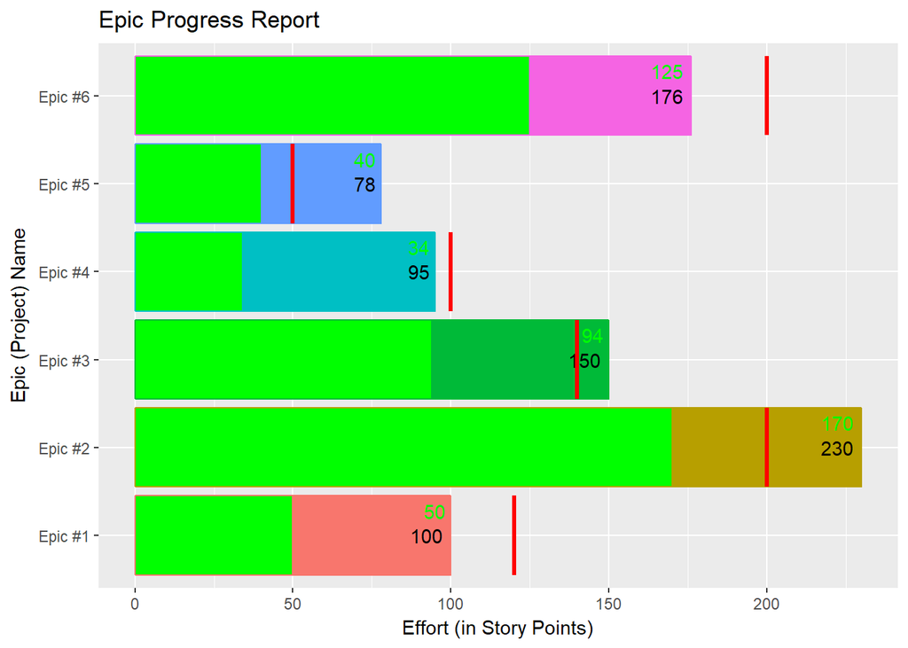

```r
generateEpicProgress(epicNames, startDates, targetDates, totalFeaturePoints, completedFeaturePoints, initialEstimates)
```

*Note: All vectors must be an equal length. This makes datasources in a table format, which are easily converted to dataframes, an ideal source.*

## Grid All Charts

To view all of these ggplot2 visuals in a gridview using gridExtra:

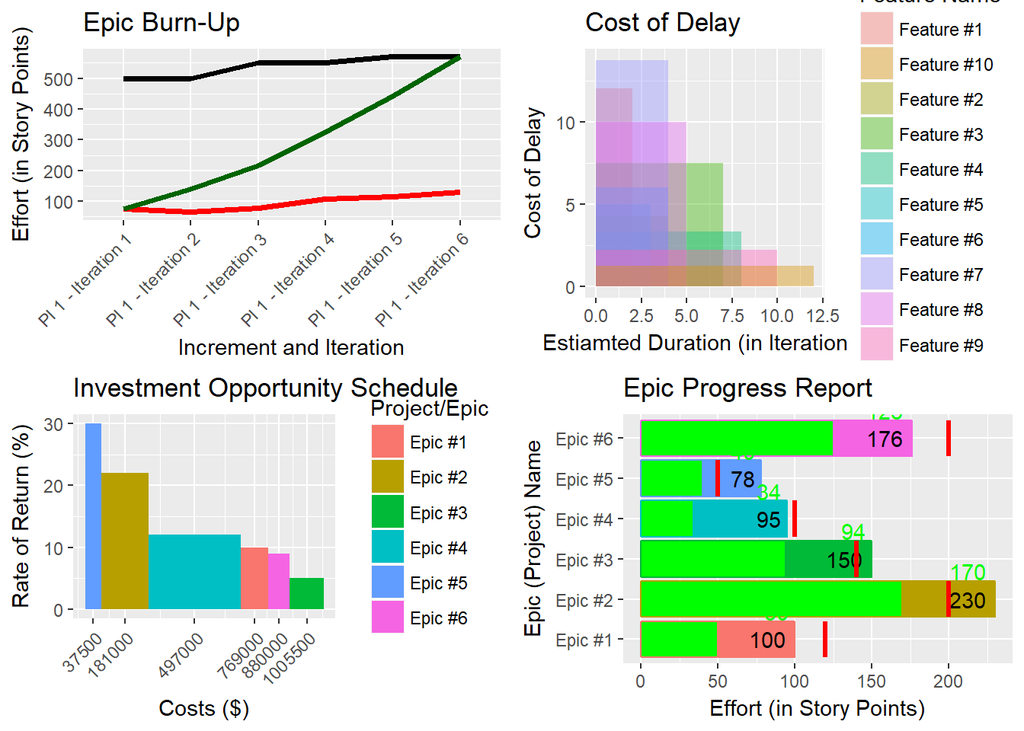